# Urban Institute R Theme Example Plots

Aaron Williams

## Introduction

R is a powerful, open-source programming language and environment. R excels at data management and munging, traditional statistical analysis, machine learning, and reproducible research, but it is probably best known for its graphics. This [Bookdown](https://bookdown.org/yihui/bookdown/) contains examples and instructions for popular and lesser-known plotting techniques in R. Furthermore, it includes instructions on how to leverage the Urban Institute’s ggplot2 theme which will create near-publication-ready plots.

The greatest strength of R is its vibrant and open community of users, developers, and educators. If you ever hit a wall, there are plenty of places to look for help. Hadley Wickham’s book, [R for Data Science](http://r4ds.had.co.nz/), is a comprehensive text for beginners. [Stackoverflow](http://stackoverflow.com/) is full of questions and answers (be sure to include “[r]” in the search). Finally, don’t hesitate to contact Alex Engler (aengler@urban.org) or Aaron Williams (awilliams@urban.org).

#### Installation

**R** can be added on any Urban Institute computer by IT.

**R Studio** is an Integrated Development Environment that greatly expands the interface and capabilites of R. Loading R Studio is the preferred way of loading R.

**R Packages** is open-source code developed by R users that contains useful functions and data that expand the power and applicability of R. Packages are regularly added on CRAN and GitHub. Most packages can be installed once with `install.packages("package name")`. This only needs to happen once on each computer. Packages can be loaded using `library(package name)`. This needs to happen at the beginning of each script for each package used. **Note:** `install.packages()` uses quotation marks while `library()` does not.

There are thousands of packages, but most tasks can be accomplished with a handful of important packages:

- `ggplot` data visualization
- `dplyr` data management
- `tidyr` data tidying
- `readr` data import
- `purrr` functional programming
- `tibble` data frames
- `hms` times
- `stringr` character strings
- `lubridate` dates/times
- `forcats` factors
- `DBI` databases
- `haven` SPSS, SAS, and Stata files
- `httr` web apis
- `jsonlite` JSON
- `readxl`.xls and .xlsx
- `rvest` web scraping
- `xml2` XML
- `modelr` simple modelling within a pipeline
- `broom` turning models into tidy data
- `tidyverse` loads all of the packages listed up to this point; see Hadley Wichkham’s “[tidyverse](https://blog.rstudio.org/2016/09/15/tidyverse-1-0-0/)”
- `shiny` interactive web applications

#### Using the Urban R Theme

Run this script once per R session

[output not shown]

This is an `R` script that can be run to make default `ggplot2` output align more closely with [the Urban Institute’s Data Visualization style guide](http://urbaninstitute.github.io/graphics-styleguide/).

  ```
  Sys.setenv(R_GSCMD="C:/Program Files/gs/gs9.05/bin/gswin32c.exe")`
  ```

**Run this script once:**

```
install.packages(c("ggplot2", "reshape2", "RColorBrewer", "extrafont"))
library(extrafont)
font_import()
loadfonts()
```

Loading and importing fonts may take a few minutes.

After the initial installation, to use Lato just load the library in each R session:

```
library(extrafont)
```

#### Grammar of Graphics and Conventions

Hadley Wickham’s ggplot2 is based on Leland Wilkinson’s grammar of graphics and Wickham’s layered grammar of graphics. The layered grammar of graphics is essentially a structured way of thinking about the components of a plot, which then lend themselves to the simple structure of ggplot2.

- **Data** are what are visualizaed in a plot and **mappings** are directions for how data are mapped in a plot in a way that can be perceived by humans.
- **Geoms** are representations of the actual data like points, lines, and bars.
- **Stats** are statistical transformations that represent summaries of the data like histograms.
- **Scales** map values in the data space to values in the aesthetic space. Scales draw legends and axes.
- **Coordinate System** describe how geoms are mapped to the plane of the graphic.
- **Facettings** break the data into meaningful subsets like small multiples.
- **Themes** control the finer points of a plot such as fonts, font sizes, and background colors.

More information: [ggplot2: Elegant Graphics for Data Analysis](https://www.amazon.com/ggplot2-Elegant-Graphics-Data-Analysis/dp/0387981403)

#### Tips and Tricks

```
ggplot(diamonds, aes(carat, price)) +
  stat_binhex(aes(colour = ..count..)) +
  theme(legend.position = "right",
        legend.direction = "vertical")
```

## Bar Plots

### One Color

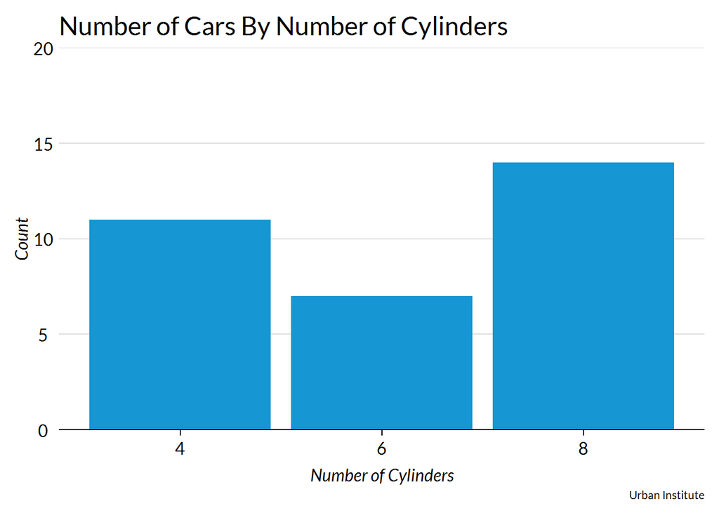

```r
ggplot(data = mtcars, mapping = aes(factor(cyl))) +
  geom_bar() +
  scale_y_continuous(expand = c(0, 0), limits = c(0, 20)) +
  labs(title = "Number of Cars By Number of Cylinders",
       caption = "Urban Institute",
       x = "Number of Cylinders",
       y = "Count")
```

### Three Colors

This is identical to the previous plot except colors and a legend are added with `fill = factor(cyl)`. Turning `x` into a factor with `factor(cyl)` skips 5 and 7 on the `x-axis`. Adding `fill = cyl` without `factor()` would have created a continuous color scheme and legend.

[figure not shown]

```r
ggplot(data = mtcars, mapping = aes(x = factor(cyl), fill = factor(cyl))) +
  geom_bar() +
  scale_y_continuous(expand = c(0, 0)) +
  labs(title = "Number of Cars By Number of Cylinders",
       caption = "Urban Institute",
       x = "Number of Cylinders",
       y = "Count"
       )
```

### Stacked Bar Plot

An additional aesthetic can easily be added to bar plots by adding `fill = categorical variable` to the mapping. Here, diamond quality subsets each bar showing the count of diamonds with each level of clarity.

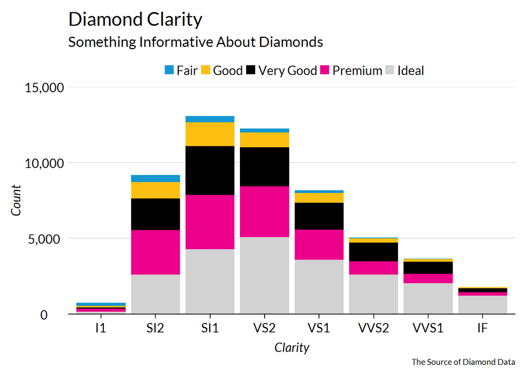

```r
ggplot(data = diamonds, mapping = aes(x = clarity, fill = cut)) +
  geom_bar() +
  scale_y_continuous(expand = c(0, 0), limits = c(0, 15000), labels = scales::comma) +
  labs(
    title = "Diamond Clarity",
    subtitle = "Something Informative About Diamonds",
    caption = "The Source of Diamond Data",
    x = "Clarity",
    y = "Count"
    )
```

### Stacked Bar Plot With Position = Fill

`position = "fill"` in `geom_bar()` changes the y-axis from count to the proportion of each bar.

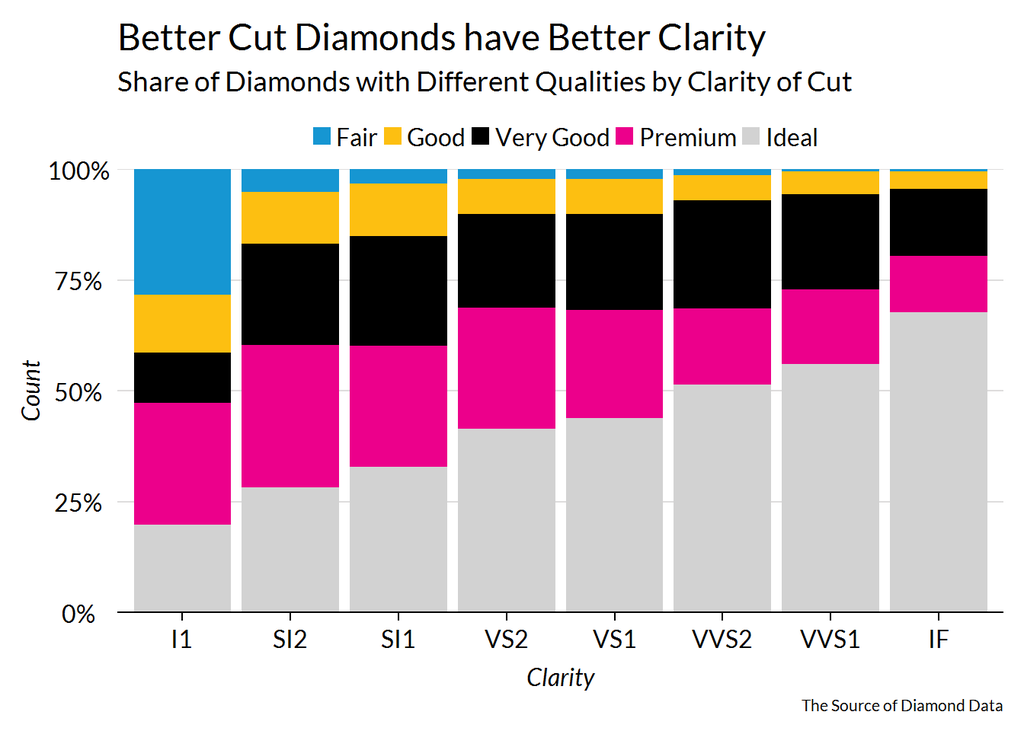

```r
#5 colors (stacked)
ggplot(data = diamonds, mapping = aes(x = clarity, fill = cut)) +
  geom_bar(position = "fill") +
  scale_y_continuous(expand = c(0, 0), labels = scales::percent) +
  labs(title = "Better Cut Diamonds have Better Clarity",
      subtitle = "Share of Diamonds with Different Qualities by Clarity of Cut",
      caption = "The Source of Diamond Data",
      x = "Clarity",
      y = "Count")
```

### Dodged Bar Plot

Subsetted bar charts in ggplot2 are stacked by default. `position = "dodge"` in `geom_bar()` expands the bar chart so the bars appear next to each other.

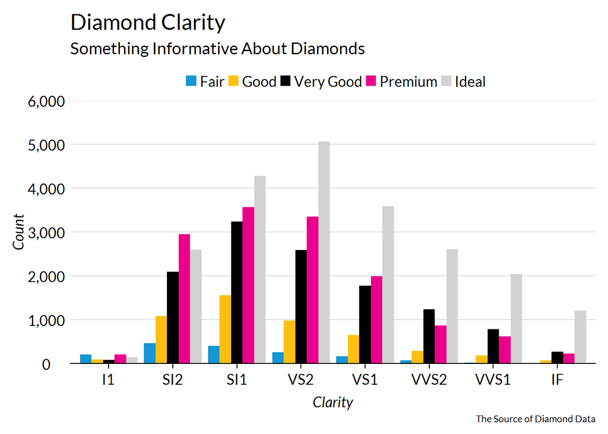

```r
#5 colors (dodged)
ggplot(data = diamonds, mapping = aes(clarity, fill = cut)) +
  geom_bar(position = "dodge") +
  scale_y_continuous(expand = c(0, 0), limits = c(0, 6000), labels = scales::comma) +
  labs(title = "Diamond Clarity",
       subtitle = "Something Informative About Diamonds",
       caption = "The Source of Diamond Data",
       x = "Clarity",
       y = "Count")
```

## Scatter Plots

### One Color Scatter Plot

Scatter plots are useful for showing relationships between two or more variables.

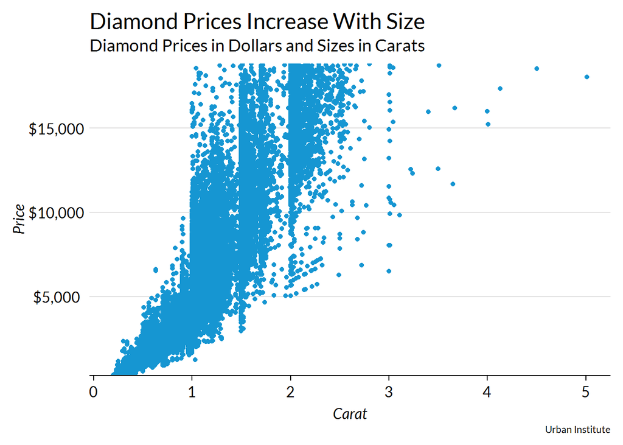

```r
ggplot(data = diamonds, mapping = aes(x = carat, y = price)) +
  geom_point() +
  scale_y_continuous(expand = c(0, 0), labels = scales::dollar) +
  labs(title = "Diamond Prices Increase With Size",
       subtitle = "Diamond Prices in Dollars and Sizes in Carats",
       caption = "Urban Institute",
       x = "Carat",
       y = "Price"
       )
```

### High-Density Scatter Plot with Transparency

Large numbers of observations can sometimes make scatter plots tough to interpret because points overlap. Adding `alpha =` with a number between 0 and 1 adds transparency to points and clarity to plots. Now it’s easy to see that jewelry stores are probably rounding up but not rounding down carats!

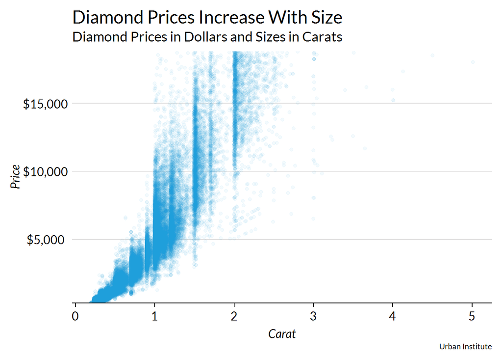

```r
ggplot(data = diamonds, mapping = aes(x = carat, y = price)) +
  geom_point(alpha = 0.05) +
  scale_y_continuous(expand = c(0, 0), labels = scales::dollar) +
  labs(title = "Diamond Prices Increase With Size",
       subtitle = "Diamond Prices in Dollars and Sizes in Carats",
       caption = "Urban Institute",
       x = "Carat",
       y = "Price"
       )
```

### Hex Scatter Plot

Sometimes transparency isn’t enough to bring clarity to a scatter plot with many observations. As n increases into the hundreds of thousands and even millions, `geom_hex` can be one of the best ways to display relationships between two variables.

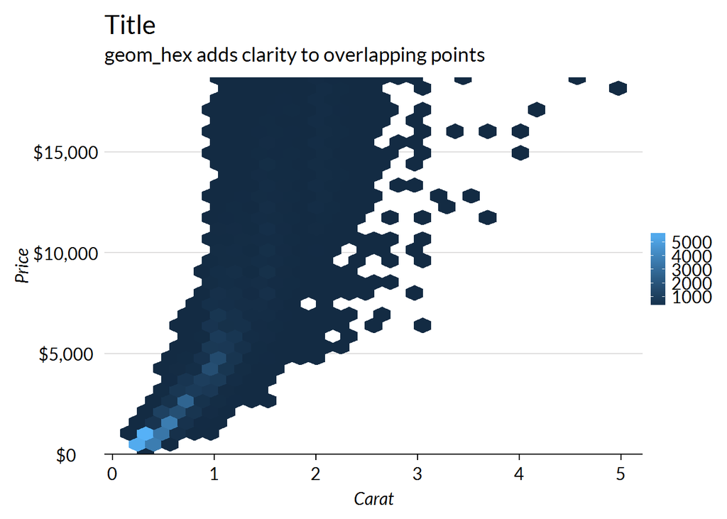

```r
ggplot(data = diamonds, mapping = aes(x = carat, y = price)) +
  geom_hex(mapping = aes(colour = ..count..)) +
  scale_y_continuous(expand = c(0, 0), labels = scales::dollar) +
  labs(title = "Title",
       subtitle = "geom_hex adds clarity to overlapping points",
       x = "Carat",
       y = "Price") +
  theme(legend.position = "right",
        legend.direction = "vertical")
```

### Scatter Plots With Random Noise

Sometimes scatter plots have many overlapping points but a reasonable number of observations. `geom_jitter` adds a small amount of random noise so points are less likely to overlap. `width` and `height` control the amount of noise that is added. In the following before-and-after, notice how many more points are visible after adding jitter.

#### Before

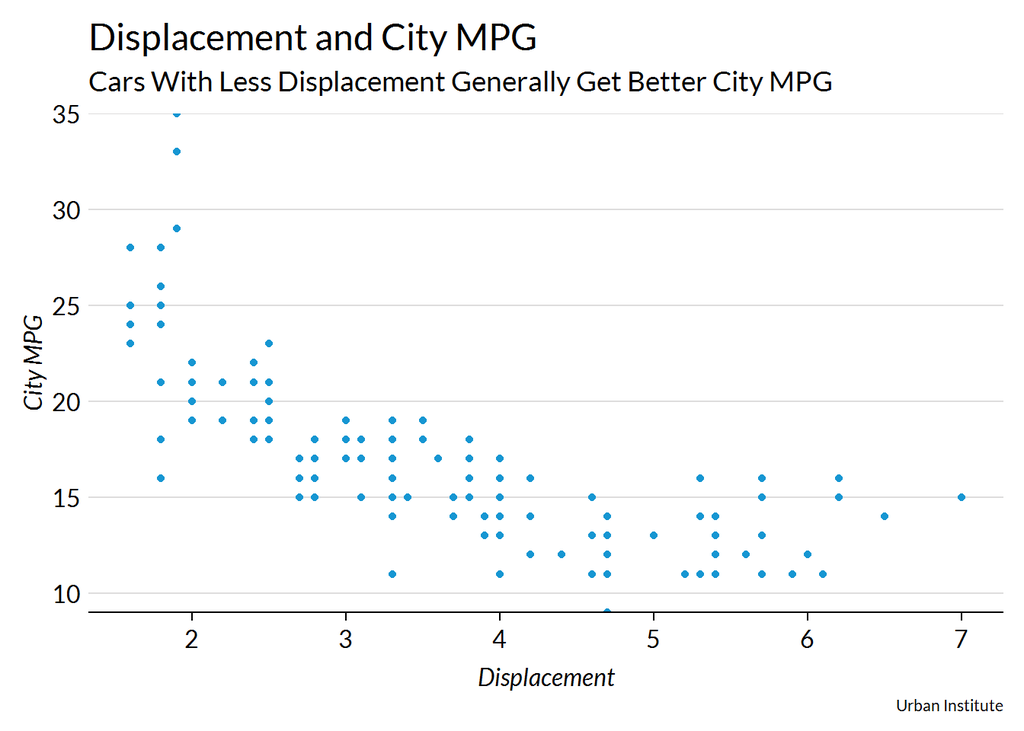

```r
ggplot(data = mpg, mapping = aes(x = displ, y = cty)) +
  geom_point() +
  scale_y_continuous(expand = c(0, 0)) +
  labs(title = "Displacement and City MPG",
       subtitle = "Cars With Less Displacement Generally Get Better City MPG",
       caption = "Urban Institute",
       x = "Displacement",
       y = "City MPG"
       )
```

#### After

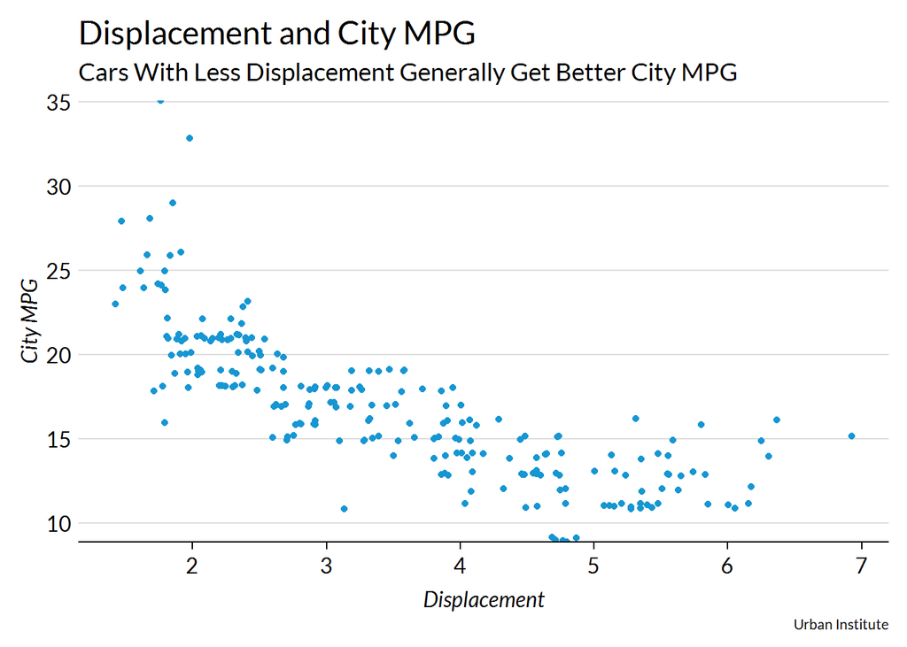

```r
set.seed(2017)
ggplot(data = mpg, mapping = aes(x = displ, y = cty)) +
  geom_jitter(width = 0.2, height = 0.2) +
  scale_y_continuous(expand = c(0, 0)) +
  labs(title = "Displacement and City MPG",
       subtitle = "Cars With Less Displacement Generally Get Better City MPG",
       caption = "Urban Institute",
       x = "Displacement",
       y = "City MPG"
       )
```

### Scatter Plots with Fill

A thired aestheitc can be added to scatter plots. Here, color signifies the number of cylinders in each car. Before `ggplot()` is called, Cylinders iscreated using `library(dplyr)` and the piping operator `%>%`.

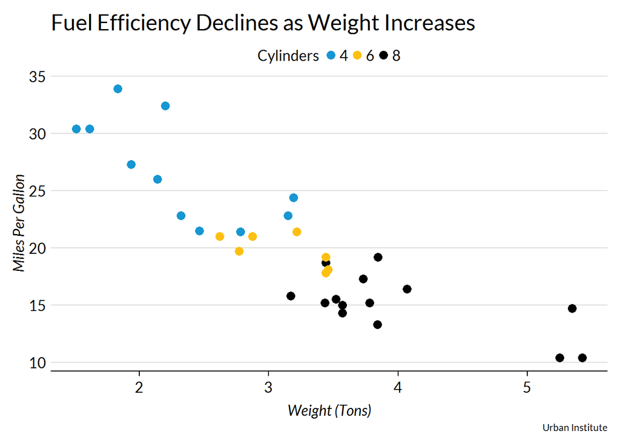

```r
mtcars %>%
  mutate(Cylinders = factor(cyl)) %>%
  ggplot(mapping = aes(x = wt, y = mpg, colour = Cylinders)) +
  geom_point(size = 3) +
  labs(title = "Fuel Efficiency Declines as Weight Increases",
       caption = "Urban Institute",
       x = "Weight (Tons)",
       y = "Miles Per Gallon") +
  theme(legend.title = element_text(hjust = 0))
```

## Line Plots

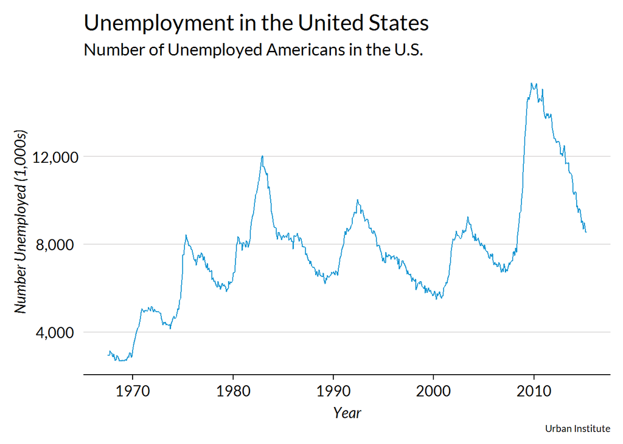

```r
ggplot(data = economics, mapping = aes(x = date, y = unemploy)) +
  geom_line() +
  scale_y_continuous(labels = scales::comma) +
  labs(title = "Unemployment in the United States",
       subtitle = "Number of Unemployed Americans in the U.S.",
       caption = "Urban Institute",
       x = "Year",
       y = "Number Unemployed (1,000s)")
```

### Lines Plots With Multiple Lines

Plotting more than one line can be useful for seeing the relationship of variables over time, but it takes a small amount of data munging.

This is because `ggplot2` wants data in a “long” format instead of a “wide” format for line plots with multiple lines. `gather()` and `spread()` from the `tidyr` package make switching back-and-forth between “long” and “wide” painless. Essentially, variable titles go into “key” and variable values go into “value”. Then ggplot2, turns the different levels of the key variable (population, unemployment) into colors.

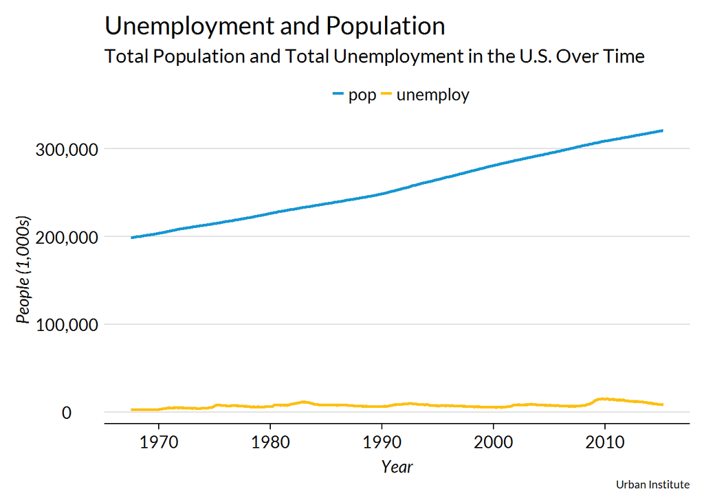

```r
library(tidyverse)

economics %>%
  select(date, pop, unemploy) %>%
  gather(pop, unemploy, key = "variable", value = "value") %>%
  ggplot(mapping = aes(x = date, y = value, color = variable)) +
  geom_line(size = 1) +
  scale_y_continuous(labels = scales::comma) +
  labs(title = "Unemployment and Population",
       subtitle = "Total Population and Total Unemployment in the U.S. Over Time",
       caption = "Urban Institute",
       x = "Year",
       y = "People (1,000s)")
```

## Binning

Histograms and frequency polygons show the distribution of a single numeric variable. Both bin variables and then count the number of observations in a bin. Histograms display distributions with a bar as a geom and frequency polygons show distributions with the line geom. Frequency polygons can be easily layered.

### Histogram

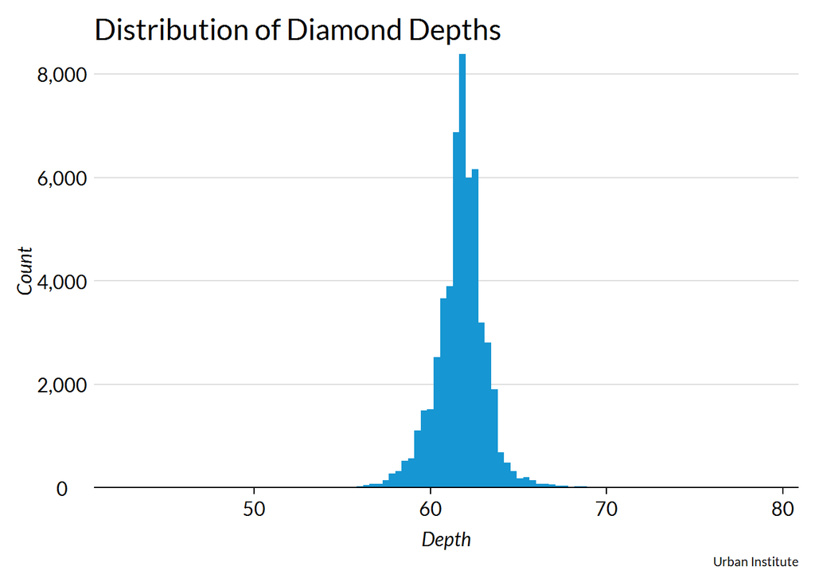

```r
ggplot(data = diamonds, mapping = aes(x = depth)) +
  geom_histogram(bins = 100) +
  scale_y_continuous(expand = c(0, 0), labels = scales::comma) +
  labs(title = "Distribution of Diamond Depths",
       caption = "Urban Institute",
       x = "Depth",
       y = "Count")
```

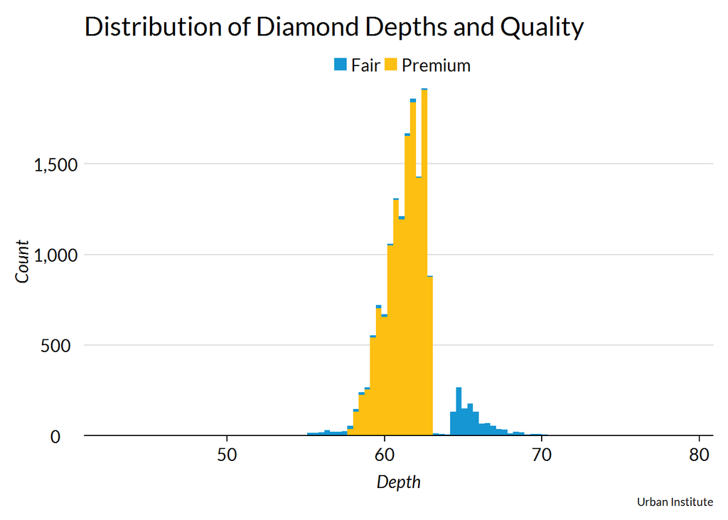

```r
diamonds %>%
  filter(cut == "Fair" | cut == "Premium") %>%
  ggplot(mapping = aes(x = depth, fill = cut)) +
  geom_histogram(bins = 100) +
  scale_y_continuous(expand = c(0, 0), labels = scales::comma) +
  labs(title = "Distribution of Diamond Depths and Quality",
       caption = "Urban Institute",
       x = "Depth",
       y = "Count")
```

### Frequency Polygon

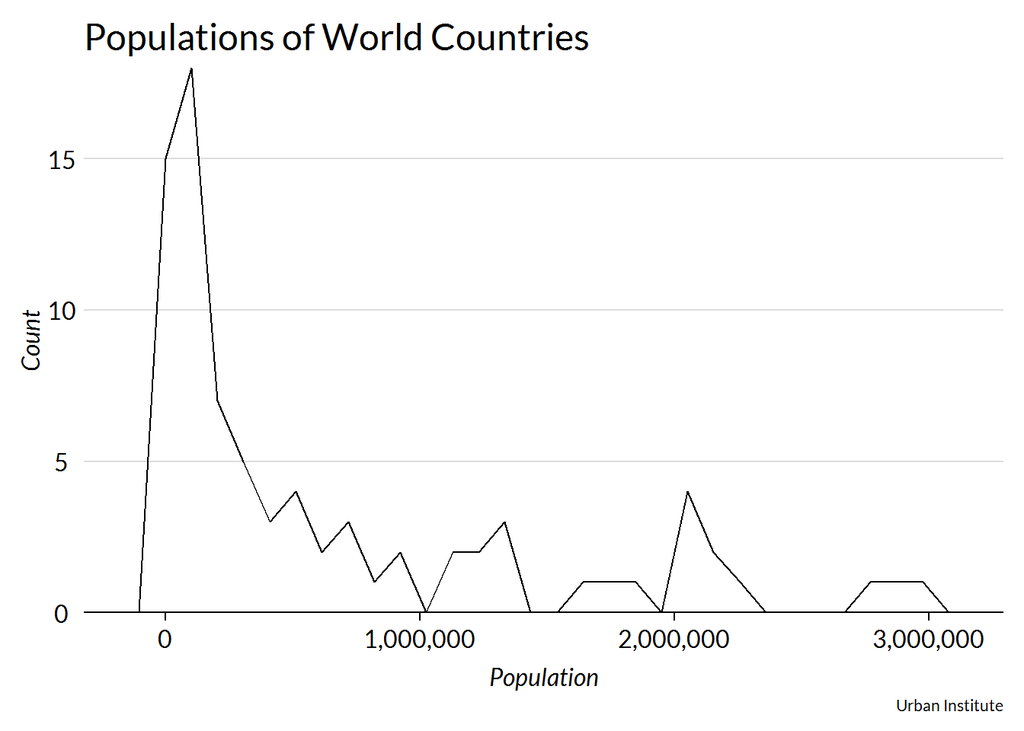

```r
population %>%
  filter(year == 2013 & population < 3000000) %>%
  ggplot(mapping = aes(x = population)) +
  geom_freqpoly() +
  scale_y_continuous(expand = c(0, 0)) +
  scale_x_continuous(labels = scales::comma) +
  labs(title = "Populations of World Countries",
       caption = "Urban Institute",
       x = "Population",
       y = "Count")
```

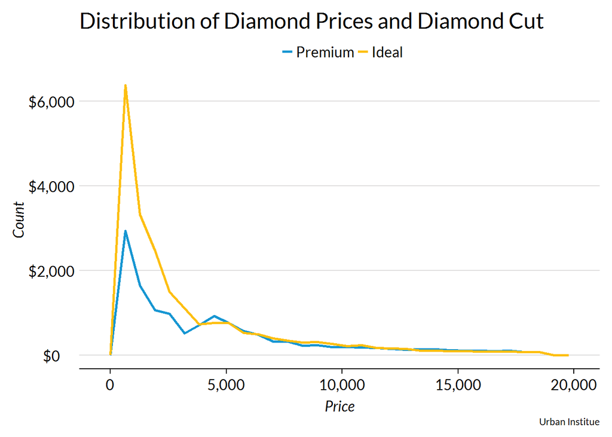

```r
diamonds %>%
  filter(cut == "Ideal" | cut == "Premium") %>%
  ggplot(aes(x = price, color = cut)) +
  geom_freqpoly(size = 1) +
  scale_x_continuous(labels = scales::comma) +
  scale_y_continuous(labels = scales::dollar) +
  labs(title = "Distribution of Diamond Prices and Diamond Cut",
       caption = "Urban Institue",
       x = "Price",
       y = "Count")
```

### Categorical Variables

The following plots are effective at displaying how a continuous variable varies across different levels of a categorical variable.

### Box Plot

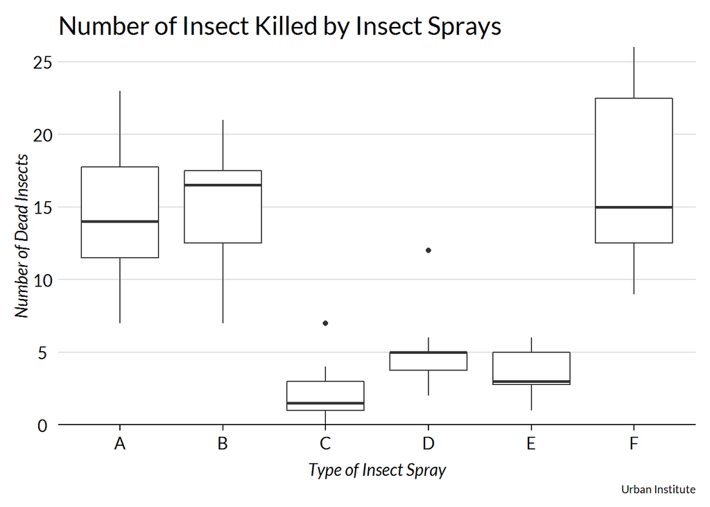

```r
ggplot(InsectSprays, aes(x = spray, y = count)) +
  geom_boxplot() +
  scale_y_continuous(expand = c(0, 0)) +
  labs(title = "Number of Insect Killed by Insect Sprays",
       caption = "Urban Institute",
       x = "Type of Insect Spray",
       y = "Number of Dead Insects")
```

### Violin Plot

[figure not shown]

```r
ggplot(InsectSprays, aes(x = spray, y = count, fill = spray)) +
  geom_violin() +
  scale_y_continuous(expand = c(0, 0)) +
  labs(title = "Number of Insect Killed by Insect Sprays",
       caption = "Urban Institute",
       x = "Type of Insect Spray",
       y = "Number of Dead Insects")
```

### Bean Plots

## Area Plot

### Stacked Area

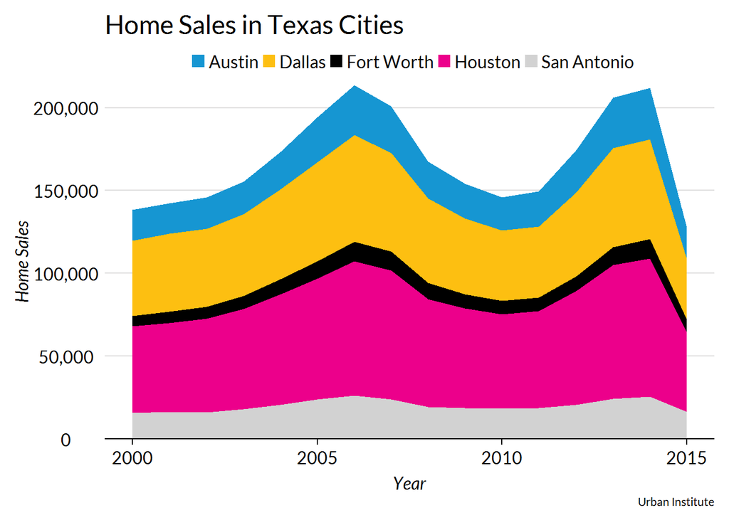

```r
txhousing %>%
  filter(city == "Austin" | city == "Houston"| city == "Dallas"| city == "San Antonio" | city == "Fort Worth") %>%
  group_by(city, year) %>%
  summarize(sales = sum(sales)) %>%
  ggplot(aes(x = year, y = sales, fill = city)) +
    geom_area(position = "stack") +
    scale_y_continuous(expand = c(0, 0), labels = scales::comma) +
    labs(title = "Home Sales in Texas Cities",
         caption = "Urban Institute",
         x = "Year",
         y = "Home Sales")
```

### Filled Area

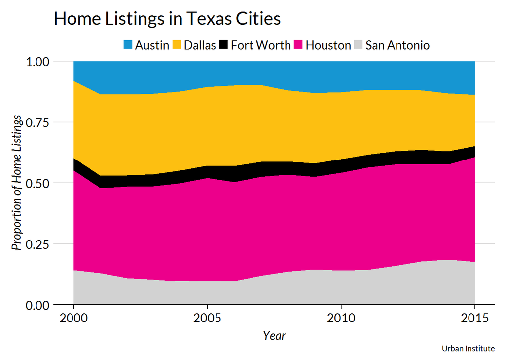

```r
txhousing %>%
  filter(city == "Austin" | city == "Houston"| city == "Dallas"| city == "San Antonio" | city == "Fort Worth") %>%
  group_by(city, year) %>%
  summarize(listings = sum(listings)) %>%
  mutate(listings = ifelse(is.na(listings), lag(listings), listings)) %>%
  ggplot(aes(x = year, y = listings, fill = city)) +
    geom_area(position = "fill") +
    scale_y_continuous(expand = c(0, 0), labels = scales::comma) +
    labs(title = "Home Listings in Texas Cities",
         caption = "Urban Institute",
         x = "Year",
         y = "Proportion of Home Listings")
```

## Waffle Chart / Square Pie Chart

The waffle package {[CRAN](https://cran.r-project.org/web/packages/waffle/waffle.pdf) and [Github](https://github.com/hrbrmstr/waffle)} makes creating square pie charts easy. It can also be combined with [glpyhs](http://fontawesome.io/) for more elegant shapes than squares. This example uses data pulled from [A Vision for an Equitable DC](http://www.urban.org/features/vision-equitable-dc).

Waffle charts will require a little extra tinkering since they are called from `library(waffle)` instead of `library(ggplot2)`. Most importantly, waffle charts require `theme_urban(text = element_text(family = "Lato"))` for the Lato font.

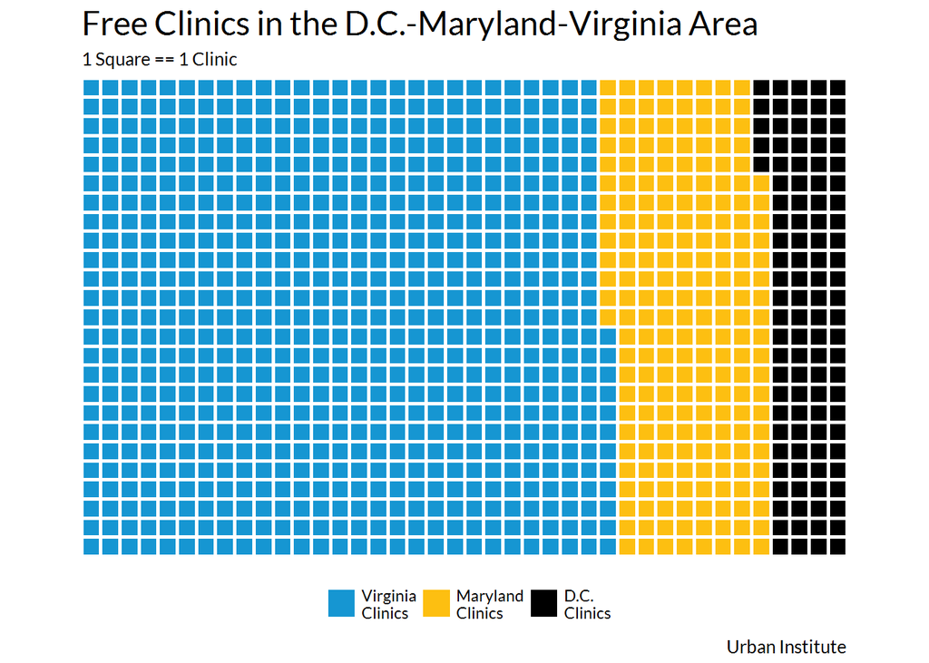

```r
library(waffle)

parts <- c(`Virginia\nClinics` = (1000 - 208 - 105), `Maryland\nClinics` = 208, `D.C.\nClinics` = 105)
waffle(parts, rows = 25, size = 1, colors = c("#1696d2", "#fdbf11", "#000000"), legend_pos = "bottom") +
  labs(title = "Free Clinics in the D.C.-Maryland-Virginia Area",
       subtitle = "1 Square == 1 Clinic",
       caption = "Urban Institute") +
  theme(text = element_text(family = "Lato"))
```

```r
white <- c(`With Degree` = 169300, `Without Degree` = 800)
black <- c(`With Degree` = 174900, `Without Degree` = 34700)
hispanic <- c(`With Degree` = 27700, `Without Degree` = 12400)

iron(
  waffle(white / 83, rows = 40, size = 0.25, colors = c("#1696d2", "#fdbf11"), title = "White", keep = FALSE, pad = 10) +
  theme(text = element_text(family = "Lato")),
  waffle(black / 83, rows = 40, size = 0.25, colors = c("#1696d2", "#fdbf11"), title = "Black", keep = FALSE) +
  theme(text = element_text(family = "Lato")),
  waffle(hispanic / 83, rows = 40, size = 0.25, colors = c("#1696d2", "#fdbf11"), title = "Hispanic", keep = FALSE, pad = 59, xlab = "1 Square == 83 People") +
  theme(text = element_text(family = "Lato"))
)
```

[figure not shown]

TODO(aaron): [add waffle plot with glyphs](https://github.com/hrbrmstr/waffle)

## Choropleth

Choropleths are maps with reagions shaded based on variables. It is simple to build choropleths in R for states and counties.

Choropleths require some data management because state or county level data need to be joined to the vector boundaries. Additionally, extra edits need to be made in `theme()` but those changes can just be copied-and-pasted from the examples.

For a more thorough explanation, read pages 55-61 of Hadley Wickham’s [ggplot2: Elegant Graphics for Data Analysis](https://www.amazon.com/ggplot2-Elegant-Graphics-Data-Analysis/dp/0387981403).

### States

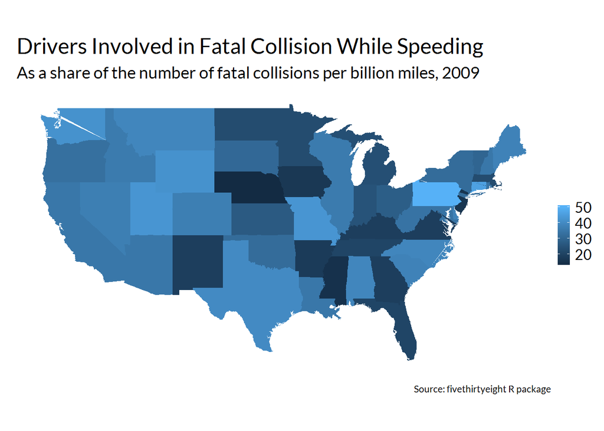

```r
library(fivethirtyeight)

# Create data frame with vector boundaries
states <- map_data("state") %>%
  select(lon = long, lat, group, state = region)

# Create data frame with state driving data
drivers.usa <- bad_drivers %>%
  mutate(state = tolower(state))

# Join the vector boundaries and state data
drivers.states <- left_join(states, drivers.usa, by = c("state" = "state"))

# Plot!
ggplot(drivers.states, aes(lon, lat, group = state)) +
  geom_polygon(aes(fill = perc_speeding)) +
  coord_quickmap() +
  labs(title = "Drivers Involved in Fatal Collision While Speeding",
       subtitle = "As a share of the number of fatal collisions per billion miles, 2009",
       caption = "Source: fivethirtyeight R package")  +
  theme(axis.text = element_blank(),
        axis.ticks = element_blank(),
        axis.title = element_blank(),
        panel.grid = element_blank(),
        axis.line = element_blank(),
        legend.position = "right",
        legend.direction = "vertical") +
  guides(colour = guide_legend(reverse = TRUE))
```

### Counties

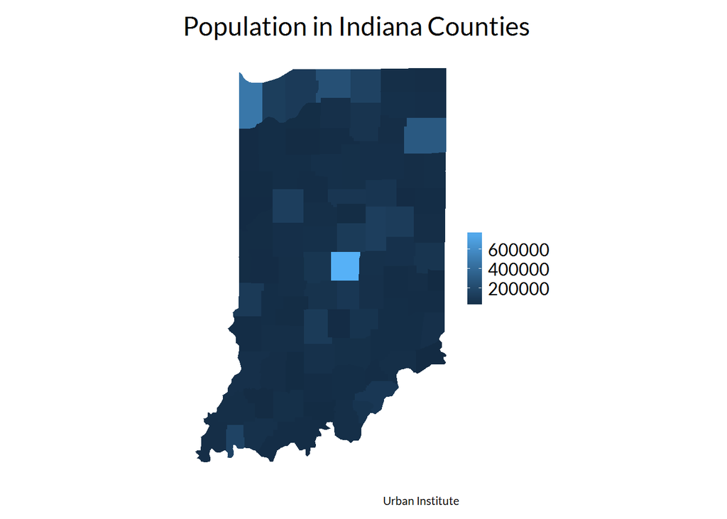

```r
library(USAboundaries)

# Create data frame with vector boundaries
indiana.counties <- map_data("county", "indiana") %>%
  select(lon = long, lat, group, id = subregion)

# Create data frame with population data
indiana.census <- midwest %>%
  tbl_df() %>%
  filter(state == "IN") %>%
  mutate(county = tolower(county)) %>%
  select(county, area, poptotal, percwhite, percblack)

# Join the vector boundaries and county data
census.counties <- left_join(indiana.census, indiana.counties, by = c("county" = "id"))

# Plot
ggplot(census.counties, aes(lon, lat, group = county)) +
  geom_polygon(aes(fill = poptotal)) +
  coord_quickmap()  +
  theme(axis.text = element_blank(),
        axis.ticks = element_blank(),
        axis.title = element_blank(),
        panel.grid = element_blank(),
        axis.line = element_blank(),
        legend.position = "right",
        legend.direction = "vertical") +
  labs(title = "Population in Indiana Counties",
       caption = "Urban Institute")
```

### Texas sales

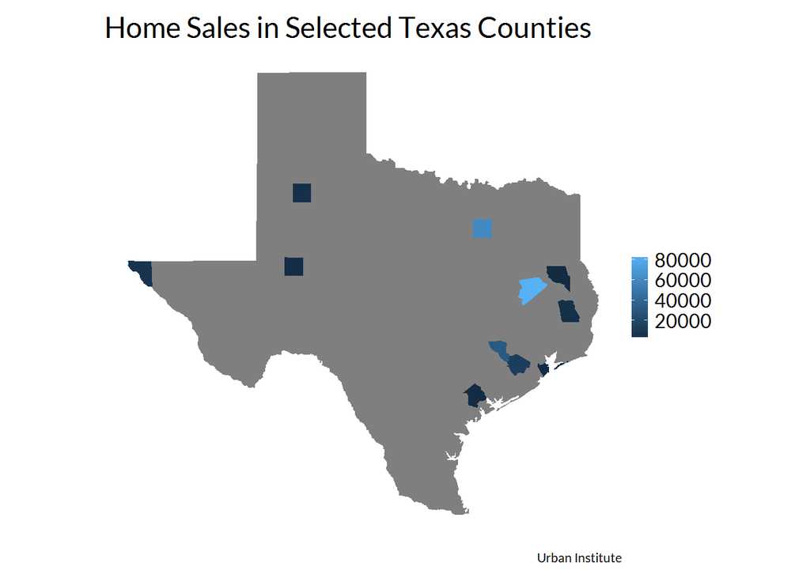

```r
library(USAboundaries)

# Create data frame with vector boundaries
texas.counties <- map_data("county", "texas") %>%
  select(lon = long, lat, group, id = subregion)

# Create data frame with hosuing data
texas.sales <- txhousing %>%
  filter(year == 2014) %>%
  select(city, sales) %>%
  mutate(city = tolower(city)) %>%
  group_by(city) %>%
  summarize(sales = sum(sales))

# Join the vector boundaries and state data
census.counties <- left_join(texas.counties, texas.sales, by = c("id" = "city"))

#Plot
ggplot(census.counties, aes(lon, lat, group = id)) +
  geom_polygon(aes(fill = sales)) +
  coord_quickmap()  +
  theme(axis.text = element_blank(),
        axis.ticks = element_blank(),
        axis.title = element_blank(),
        panel.grid = element_blank(),
        axis.line = element_blank(),
        legend.position = "right",
        legend.direction = "vertical") +
  labs(title = "Home Sales in Selected Texas Counties",
       caption = "Urban Institute")
```

### Dot Map

### DC Crime Map

## Heat map

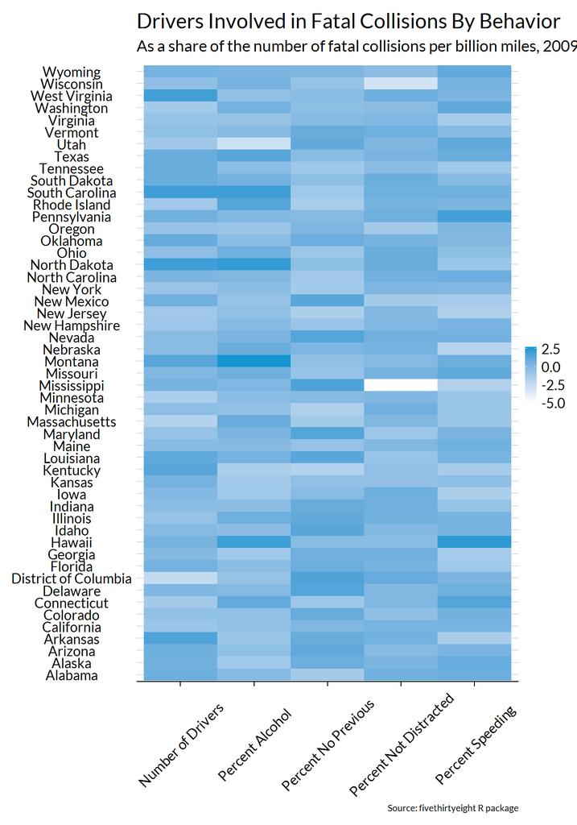

```r
bad_drivers %>%
  mutate(`Number of Drivers` = scale(num_drivers)) %>%
  mutate(`Percent Speeding` = scale(perc_speeding)) %>%
  mutate(`Percent Alcohol` = scale(perc_alcohol)) %>%
  mutate(`Percent Not Distracted` = scale(perc_not_distracted)) %>%
  mutate(`Percent No Previous` = scale(perc_no_previous)) %>%
  select(-insurance_premiums, -losses, -(num_drivers:losses)) %>%
  gather(`Number of Drivers`:`Percent No Previous`, key = "variable", value = "SD's from Mean") %>%
  ggplot(aes(variable, state)) +
  geom_tile(aes(fill = `SD's from Mean`)) +
  labs(title = "Drivers Involved in Fatal Collisions By Behavior",
       subtitle = "As a share of the number of fatal collisions per billion miles, 2009",
       caption = "Source: fivethirtyeight R package",
       x = NULL,
       y = NULL) +
  scale_fill_gradient(low = "white", high = "#1696d2") +
  theme(legend.position = "right",
        legend.direction = "vertical",
        axis.text.x = element_text(angle = 45))
```

```r
#https://learnr.wordpress.com/2010/01/26/ggplot2-quick-heatmap-plotting/
```

## Facetting

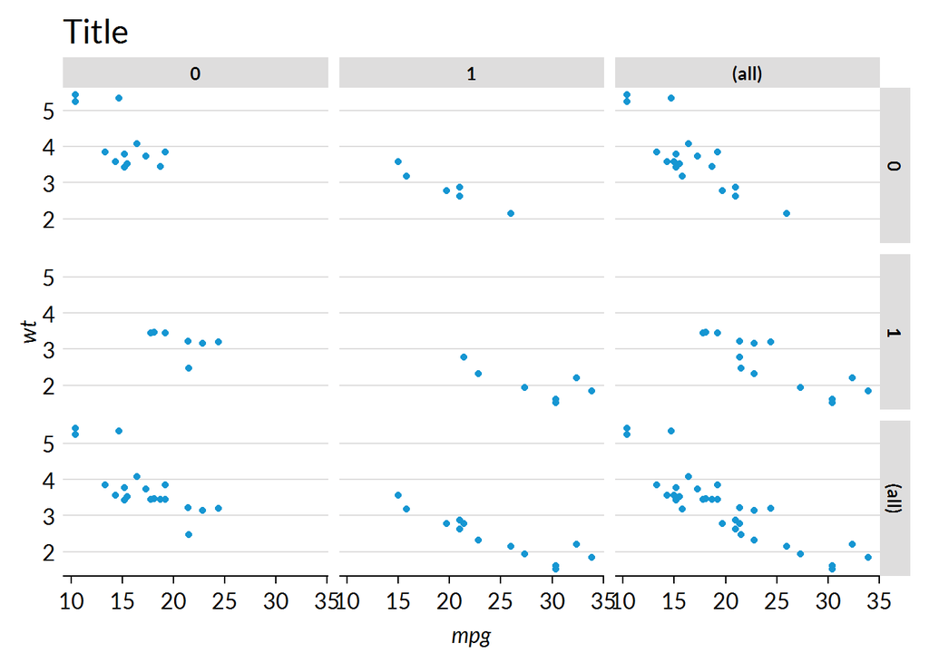

```r
##Facet Grid
ggplot(mtcars, aes(mpg, wt)) +
  geom_point() +
  ggtitle("Title") +
  facet_grid(vs ~ am, margins = TRUE)
```

## Small Multiples

R’s facetting system is a powerful way to make “small multiples”.

Some edits to the theme may be necessary depending upon how many rows and columns are in the plot.

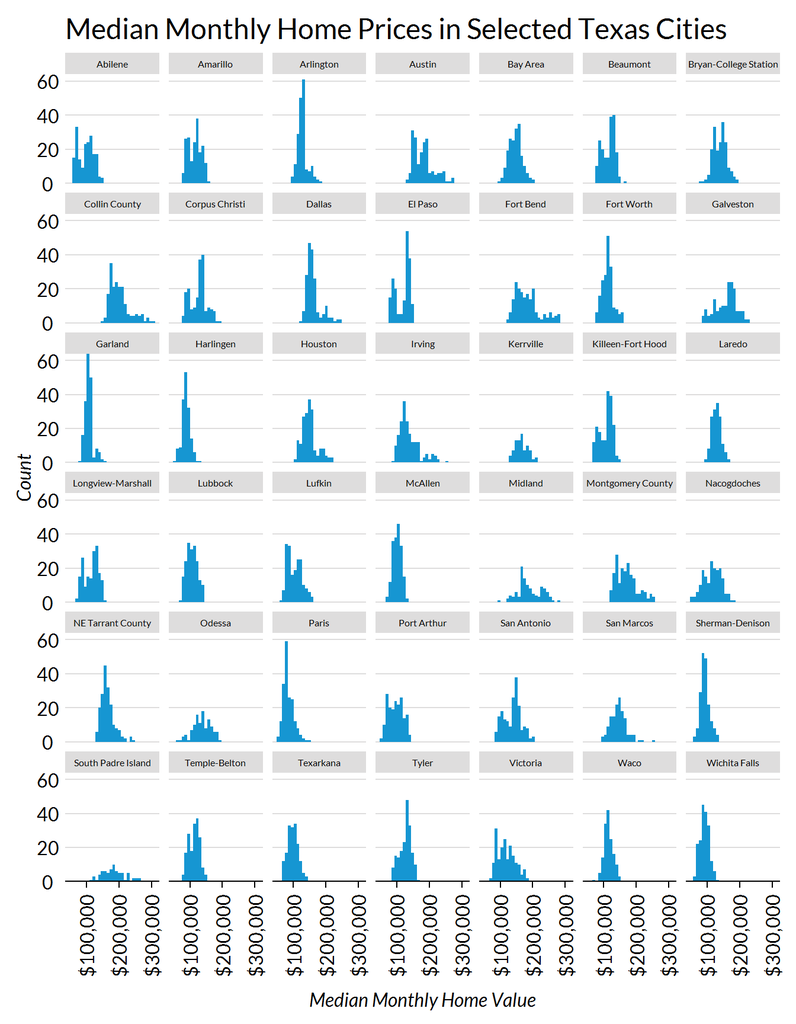

```r
# Facet Wrap
txhousing %>%
  filter(city != "Brazoria County" & city != "Brownsville" & city != "San Angelo" & city != "Denton County") %>%
  ggplot(aes(x = median)) +
  geom_histogram() +
  facet_wrap(~city) +
  scale_x_continuous(labels = scales::dollar) +
  scale_y_continuous(expand = c(0, 0)) +
  labs(title = "Median Monthly Home Prices in Selected Texas Cities",
       x = "Median Monthly Home Value",
       y = "Count") +
  theme(axis.text.x = element_text(angle = 90),
        strip.text = element_text(face = "plain",
                              size = rel(0.5)))
```

```r
# Facet grid
```

## Loess

### Smoothers

## Combining Geoms

## Shiny

## ggvis